# mlr3 Imputation: An Introduction

Natalie Foss

2022-09-19

# Introduction

This post is a part of a series about `mlr3`, see the other posts:

- Create your first R Project: [link](https://nfoss2.github.io/mlr3_first_project_post)
- Learn the right way to train simple models: [link](https://nfoss2.github.io/mlr3_models_post)
- Learn how to benchmark different learners (with different challenges) (this post)

The purpose of this post is to introduce you to `mlr3` benchmarking, imputation, and encoding and give an example of how to benchmark using pipelines (showing the best practice methods), using the `palmer penguins` dataset. `palmer penguins` is a built in task described as “classification data to predict the species of penguins”. Read more about the dataset [here](https://mlr3.mlr-org.com/reference/mlr_tasks_penguins.html).

## Set Up the Environment

To follow along with this post you will to run the following code chunk:

```r
set.seed(78)
# install.packages("knitr")
library(knitr)
# install.packages("mlr3")
library("mlr3")

# create task object
task = tsk("penguins")

# create a resampling object
cv = rsmp("cv", folds=10)

# create a performance measure object
measure = msr("classif.ce")
```

### Review

Our chosen task `penguins` has the following properties we will keep in mind:

```r
task
```

```
## <TaskClassif:penguins> (344 x 8): Palmer Penguins
## * Target: species
## * Properties: multiclass
## * Features (7):
##   - int (3): body_mass, flipper_length, year
##   - dbl (2): bill_depth, bill_length
##   - fct (2): island, sex
```

- It is multiclass and has missing values
- Its feature types are numeric and factor

### Missing Values

Many data sets have missing values, this can cause issues with some learners. To see if your data set has missing values use `$missings()`

```r
task$missings()
```

```
##        species     bill_depth    bill_length      body_mass flipper_length
##              0              2              2              2              2
##         island            sex           year
##              0             11              0
```

## Goal

In this post we want to see the best practice method of comparing three different classification learners on the `pengiuns` task. Each learner has different requirements:

1. `classif.rpart` is a great basic learner since it tends to accommodate most feature types and properties:

```r
# install.packages("mlr3learners")
library(mlr3learners)
lrn("classif.rpart")
```

```
## <LearnerClassifRpart:classif.rpart>: Classification Tree
## * Model: -
## * Parameters: xval=0
## * Packages: mlr3, rpart
## * Predict Types:  [response], prob
## * Feature Types: logical, integer, numeric, factor, ordered
## * Properties: importance, missings, multiclass, selected_features,
##   twoclass, weights
```

2. `classif.naive_bayes` is a learner that cannot deal with missing values (our dataset contains missing values), so we will need to correct for that.

```r
# install.packages("e1071") # for `classif.naive_bayes`
library(e1071)
lrn("classif.naive_bayes")
```

```
## <LearnerClassifNaiveBayes:classif.naive_bayes>
## * Model: -
## * Parameters: list()
## * Packages: mlr3, mlr3learners, e1071
## * Predict Types:  [response], prob
## * Feature Types: logical, integer, numeric, factor
## * Properties: multiclass, twoclass
```

3. `classif.xgboost` is a learner that cannot deal with factor feature types (our dataset has some factor feature types), so we will need to correct for that.

```r
# install.packages("xgboost")
library(xgboost)
lrn("classif.xgboost")
```

```
## <LearnerClassifXgboost:classif.xgboost>
## * Model: -
## * Parameters: nrounds=1, nthread=1, verbose=0
## * Packages: mlr3, mlr3learners, xgboost
## * Predict Types:  [response], prob
## * Feature Types: logical, integer, numeric
## * Properties: hotstart_forward, importance, missings, multiclass,
##   twoclass, weights
```

## What is Imputation?

**Imputation** is a method of identifying and handling (removing or replacing) missing values in a data set.

There are many different kinds of imputation, most have `mlr3` implementations. Short explanations of each are in this table.

Imputation methods

| Imputation Method | Description | Parameters | Link to Docs |
| --- | --- | --- | --- |
| “imputeconstant” | Replaces all missing values with a constant. | `constant` | Read more [here](https://mlr3pipelines.mlr-org.com/reference/mlr_pipeops_imputeconstant.html). |
| “imputehist” | Replaces all missing values from a histogram. |  | Read more [here](https://mlr3pipelines.mlr-org.com/reference/mlr_pipeops_imputehist.html). |
| “imputelearner” | Replaces all missing values by fitting a learner. | `learner` | Read more [here](https://mlr3pipelines.mlr-org.com/reference/mlr_pipeops_imputelearner.html). |
| “imputemean” | Replaces all numerical missing values with the mean or the column. |  | Read more [here](https://mlr3pipelines.mlr-org.com/reference/mlr_pipeops_imputemean.html). |
| “imputemedian” | Replaces all numerical missing values with the median or the column. |  | Read more [here](https://mlr3pipelines.mlr-org.com/reference/mlr_pipeops_imputemedian.html). |
| “imputemode” | Replaces all numerical missing values with the mode or the column. |  | Read more [here](https://mlr3pipelines.mlr-org.com/reference/mlr_pipeops_imputemode.html). |
| “imputeoor” | Replaces all numerical missing values with constant values shifted below the minimum or above the maximum. This method is useful in the context of tree-based methods. | `min`, `offset`, `multiplier` | Read more [here](https://mlr3pipelines.mlr-org.com/reference/mlr_pipeops_imputeoor.html). |
| “imputesample” | Replaces all numerical missing values by sampling from the non-missing training data. |  | Read more [here](https://mlr3pipelines.mlr-org.com/reference/mlr_pipeops_imputesample.html). |

## What is Encoding?

Encoding is a method of making categorical/factor features into numeric features that can be used with learners that only deal in numeric feature types. The two features that are factor type in our data set are “island” and “sex”. Since these do not have a natural rank or ordering we will use one-hot encoding. Read more about encoding [here](https://machinelearningmastery.com/one-hot-encoding-for-categorical-data/).

## Create the Learners

### Rpart

First we will create the `classif.rpart` learner. This is the simplest one because it requires no data pre-processing.

```r
RPLrn = lrn("classif.rpart")
```

### naive_bayes

```r
# install.packages("mlr3pipelines")
library("mlr3pipelines")
```

The next learner we want to test is `classif.naive_bayes` which requires us to impute the missing values. Since there is more than one step we will wrap the imputation and learner in a graph learner.

Step 1: Create necessary PipeOps (imputation and learner)

```r
# imputation method
poImpute = po("imputesample")

# Learner PipeOP
poNBLrn = po("learner", learner = lrn("classif.naive_bayes"))
```

Step 2: Create a graph with imputation and learner

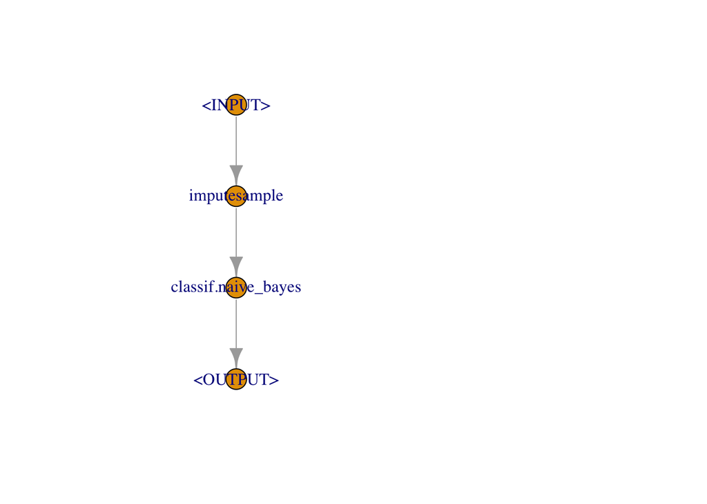

```r
graph1 = poImpute %>>% poNBLrn
graph1$plot()
```

Step 3: Cast the graph as a graph learner

```r
NBLrn = as_learner(graph1)
```

### Xgboost

The next learner we want to test is `classif.xgboost` which requires us to encode the factor type features. Since there is more than one step we will wrap the imputation and learner in a graph learner.

Step 1: Create necessary PipeOps (encoding and learner)

```r
# encode PipeOp
poEnc = po("encode")

# Learner PipeOP
poXGLrn = po("learner", learner = lrn("classif.xgboost"))
```

Step 2: Create a graph with encoding and learner

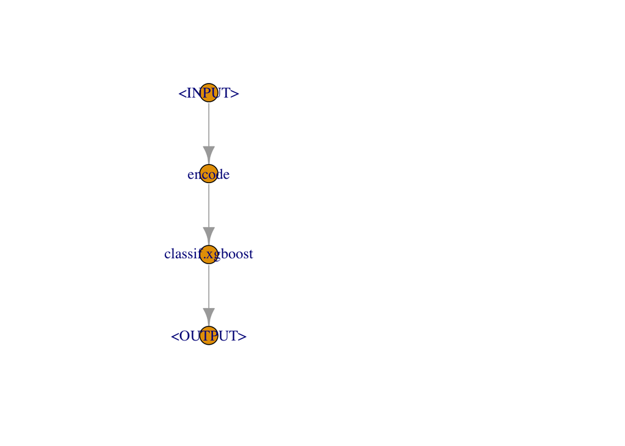

```r
graph2 = poEnc %>>% poXGLrn
graph2$plot()
```

Step 3: Cast the graph as a graph learner

```r
XGLrn = as_learner(graph2)
```

## Create Benchmarking Design

```r
library("mlr3verse")
```

In the benchmark design we will specify the task (`penguins`), learners (`RPLrn`, `NBLrn`, and `XGLrn`), resamplings (`cv`)

```r
design = benchmark_grid(
  task = task,
  learners = c(RPLrn, NBLrn, XGLrn),
  resampling = cv
)
```

Once the benchmark design is ready we can call `benchmark()` on it.

```r
bmr = benchmark(design)
```

[output not shown]

Now lets look at the results

```r
table = bmr$aggregate(measure)
kable(table)
```

| nr | resample_result | task_id | learner_id | resampling_id | iters | classif.ce |
| --- | --- | --- | --- | --- | --- | --- |
| 1 | <environment: 0x7fc6ef0ed858> | penguins | classif.rpart | cv | 10 | 0.0555462 |
| 2 | <environment: 0x7fc6ef108438> | penguins | imputesample.classif.naive_bayes | cv | 10 | 0.0175630 |
| 3 | <environment: 0x7fc6ee359e08> | penguins | encode.classif.xgboost | cv | 10 | 0.0202521 |

We can see that in this case the imputation and naive_bayes method had the best performance (0.017563025210084 classification error) then the encoding and xgboost method (0.0202521008403361 classification error) then lastly the simple rpart method (0.055546218487395classification error). Many learners cannot accommodate missing values (see [this list](https://mlr-org.com/learners.html) and look for `missings` in properties for those that can) so knowing how to impute these missing values can allow you to explore more models and maybe even get better performance.